# The Participation Puzzle: Gender Disparities in Unpaid Care Work in India

Your Name

2025-11-13

Gender inequality in unpaid care work constitutes a fundamental mechanism reproducing economic disadvantage across generations. Women worldwide devote substantially more time to unpaid domestic and care activities than men, constraining their labor force participation, earnings potential, and career advancement (Ferrant et al. 2014; Folbre 2006). Yet the precise nature of this disparity—whether rooted in differential participation rates or differential time intensity conditional on participation—remains empirically underexplored.

This distinction matters. If gender gaps stem from women working longer hours when performing care activities, interventions might focus on redistributing workload among current participants through household bargaining or service provision. If gaps instead reflect lower male participation rates at similar intensities, policy must target the cultural norms and institutional structures that exempt men from care responsibilities entirely.

Women’s disproportionate responsibility for unpaid domestic and care work represents one of the most persistent forms of gender inequality globally. Ferrant et al. (2014) document that women perform 2-10 times more unpaid care work than men across 66 countries. This disparity has direct economic consequences: Folbre (2006) shows unpaid care work constrains women’s labor force participation and Goldin (2014) demonstrates it contributes to gender wage gaps.

Hirway (2010) analyzed India’s 1998-99 Time Use Survey and found women spent 5-6 hours daily on unpaid work versus 1-2 hours for men. Chakraborty et al. (2018) confirmed persistent disparities with 2019 data. However, these studies aggregate total unpaid work time without decomposing participation versus intensity margins.

Bargaining models (Becker 1991; Lundberg and Pollak 1996) emphasize within-household negotiation based on relative earning power. Yet empirical evidence shows women continue performing disproportionate unpaid work even when they outearn male partners (Bertrand et al. 2015). Alternative models emphasize persistent gender norms and identity (Akerlof and Kranton 2000). Our finding that participating men work similar intensities to women but far fewer men participate is more consistent with norm-based than bargaining explanations.

```
## Total observations: 10,211,478
```

```
## Major activities: 8,356,660
```

India’s Time Use Survey 2024, conducted by the National Statistical Office, employed a stratified multi-stage sample design covering all states and union territories. The survey recorded detailed time diaries for all household members aged 6 and above, capturing activities in 30-minute intervals over 24 hours.

Gender is coded male/female/transgender. We additionally examine variation by age, marital status, education, sector (rural/urban), and household composition.

All estimates use provided survey weights to ensure national representativeness.

The survey employs the International Classification of Activities for Time Use Statistics (ICATUS). We focus on code 02 (unpaid care for children, sick, elderly, and differently-abled household members) as our primary care work measure.

Distribution of Unpaid/Paid Status Codes

| Var1 | Freq |
| --- | --- |
| 01 | 6228238 |
| 02 | 274101 |
| 03 | 1242660 |
| 04 | 133702 |
| 06 | 6413 |
| 07 | 416 |
| 08 | 370 |
| 10 | 191 |
| 13 | 137044 |
| 14 | 90687 |
| 15 | 31621 |
| 16 | 100241 |
| 17 | 91792 |
| 18 | 19184 |

Participation and Time Intensity in Care Work

| Gender | N | Care Activities | Participation (%) | Minutes/Participant | Minutes/Person |
| --- | --- | --- | --- | --- | --- |
| Male | 3889918 | 60498 | 1.56 | 50.70 | 0.77 |
| Female | 4465786 | 213566 | 4.78 | 47.36 | 2.25 |

Table 1 presents our core finding. Women participate in unpaid care work at 4.78% daily frequency versus 1.56% for men—a 3.06-fold difference. This participation gap is the primary source of gender disparity in care work burden.

Yet conditional on participation, the gender gap vanishes. Men who perform care work spend 50.7 minutes per activity versus 47.4 minutes for women—a statistically insignificant 3.3-minute difference.

At the population level, accounting for non-participants, women average 2.25 minutes daily care work versus 0.77 minutes for men. This 2.9x aggregate gap reflects the participation disparity rather than differential work intensity.

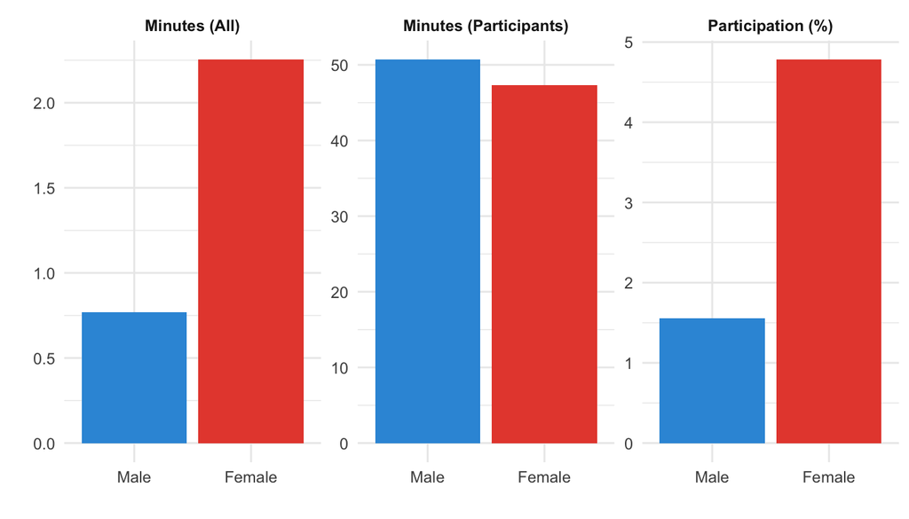

Gender Gap in Care Work: Participation vs. Intensity

Care Work by Age Group

| age_group | participation_rate_Male | participation_rate_Female | minutes_per_person_Male | minutes_per_person_Female |
| --- | --- | --- | --- | --- |
| <25 | 0.44 | 3.68 | 0.25 | 1.81 |
| 25-34 | 3.47 | 10.58 | 1.75 | 4.80 |
| 35-44 | 2.29 | 2.95 | 1.00 | 1.22 |
| 45-54 | 0.77 | 2.04 | 0.38 | 1.14 |
| 55+ | 1.13 | 2.38 | 0.60 | 1.33 |
| NA | 0.00 | 0.23 | 0.00 | 0.04 |

Care Work Participation by Education and Sector (%)

| education | Male_Rural | Male_Urban | Female_Rural | Female_Urban |
| --- | --- | --- | --- | --- |
| Higher | 2.18 | 2.05 | 6.99 | 6.07 |
| Primary or less | 1.28 | 1.06 | 3.76 | 3.29 |
| Secondary | 1.74 | 1.43 | 6.08 | 4.99 |

Care Activities by Type (Participants Only)

| Gender | Activity Type | Avg Minutes | N Activities |
| --- | --- | --- | --- |
| Male | Adult care | 42.4 | 17654 |
| Male | Child care | 46.4 | 30280 |
| Male | Non-household care | 61.9 | 4176 |
| Female | Adult care | 40.8 | 198922 |
| Female | Child care | 49.6 | 756342 |
| Female | Non-household care | 65.0 | 1819 |

Women perform vastly more child care activities than men, but when men do participate, they spend similar durations per activity. This pattern holds across all care types.

Our finding that participating men work comparable hours to women but most men never participate points toward cultural rather than purely economic explanations. If women performed care work because of comparative advantage or lower market wages (Becker 1991), we would expect differences in time intensity conditional on participation. Instead, the data suggest a categorical norm: care work is women’s work.

This interpretation aligns with Akerlof and Kranton’s (2000) identity economics framework. If performing care work violates masculine identity, men will avoid it entirely rather than simply doing less. The near-equivalence of care work intensity among participants across genders suggests that once the identity barrier is crossed, the work itself is similarly demanding.

The care work participation gap perpetuates women’s economic disadvantage. Goldin (2014) shows gender wage gaps concentrate in occupations demanding long, inflexible hours—precisely the jobs incompatible with primary care responsibility. Kleven et al. (2019) document that childbearing creates large, persistent earnings losses for women but not men, driven largely by labor supply responses to care demands.

By identifying low male participation as the binding constraint, our results suggest that equalizing care work requires bringing men in rather than simply reducing women’s burdens.

Women in India bear a disproportionate burden of unpaid care work, performing care activities at rates more than three times higher than men. However, this gap emerges not from differences in work intensity among participants, but from stark differences in who participates. When men do engage in care work, they work comparable hours to women. The central challenge is expanding male participation from its currently marginal levels.

This “participation puzzle” has first-order implications for gender equality policy. Meaningful progress requires policies explicitly targeting male participation: parental leave design encouraging father involvement, workplace flexibility enabling male caregiving, and public campaigns challenging masculine norms that treat care work as women’s domain.

We gratefully acknowledge Dr. Tanu Goel and Chellsea from the Indian Council for Research on International Economic Relations (ICRIER) for their invaluable support in accessing and understanding the Time Use Survey data. We also thank the National Statistical Office, India for conducting and disseminating the survey.